# Hedgehog density on the Otago Peninsula

Charlotte R. Patterson

This code analyses spatially explicit capture-recapture data from van Heezik, Simpson, Patterson, Wilson & Seddon (2023).

## Initial setup

Load packages and set working directory.

```r
#install.packages("secr")
library(tidyverse)
packages <- c("secr", "here")
walk(packages, require, character.only = T)

here::i_am("./Hedgehog_density_Otago_Peninsula_code.Rmd")
```

Import capture and trap files and view summary.

```r
CH <- read.capthist("captfile.txt","trapfile.txt",detector="multi")
```

```
## No errors found :-)
```

```r
summary(CH)
```

```
## Object class       capthist
## Detector type      multi
## Detector number    89
## Average spacing    91.01169 m
## x-range            471170.6 472397.4 m
## y-range            4920680 4921930 m
##
## Counts by occasion
##                    1  2  3  4  5  6  7  8  9 10 11 12 13 14 15 Total
## n                  4  4  1  4  2  5  3  7  0  1  3  4  4  4  3    49
## u                  4  3  1  4  2  5  1  5  0  1  1  0  2  1  1    31
## f                 23  4  1  1  1  1  0  0  0  0  0  0  0  0  0    31
## M(t+1)             4  7  8 12 14 19 20 25 25 26 27 27 29 30 31    31
## losses             0  0  0  0  0  0  0  0  0  0  0  0  0  0  0     0
## detections         4  4  1  4  2  5  3  7  0  1  3  4  4  4  3    49
## detectors visited  4  4  1  4  2  5  3  7  0  1  3  4  4  4  3    49
## detectors used    89 89 89 89 89 89 89 89 89 89 89 89 89 89 89  1335
```

Plot recaptures.

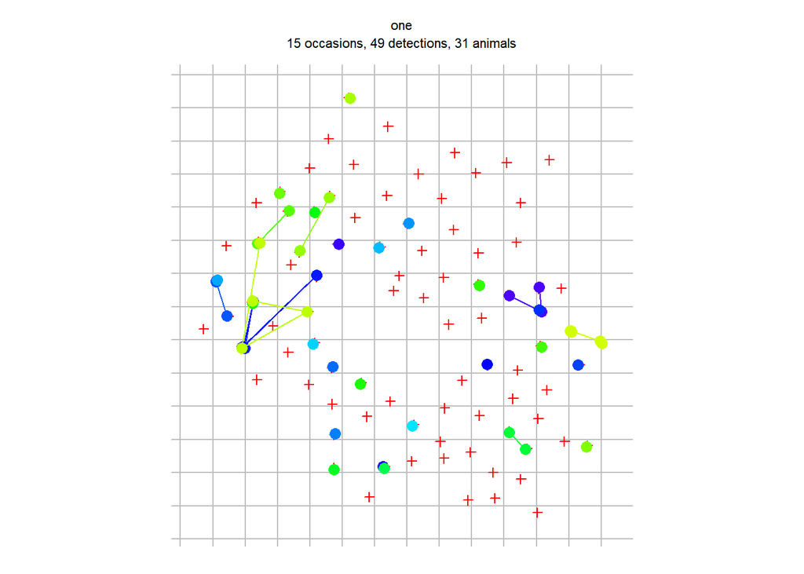

```r
par(mar = c(1,1,3,1)) # reduce margins
##plot
plot(CH, tracks = TRUE)
```

View successive trap-revealed movement distances, summarise with the median and a histogram. Observing that quite a few individuals were showing movements > 90 m (our trap spacing) suggests that even individuals with home range centres outside of the trapping grid would have had the opportunity to be caught (Efford, 2022).

```r
m <- unlist(moves(CH))
m
```

```
##        11        12        61        62        63        64         9        18
## 110.93082  64.66250 312.11123 312.11123 140.06706 140.06706 110.74957  76.16208
##        25        28       301       302       303       311       312       313
## 129.06178 193.72504 322.36964 228.83173 177.50382   0.00000  99.30422   0.00000
##       314       315
##   0.00000   0.00000
```

```r
median(m)
```

```
## [1] 119.9963
```

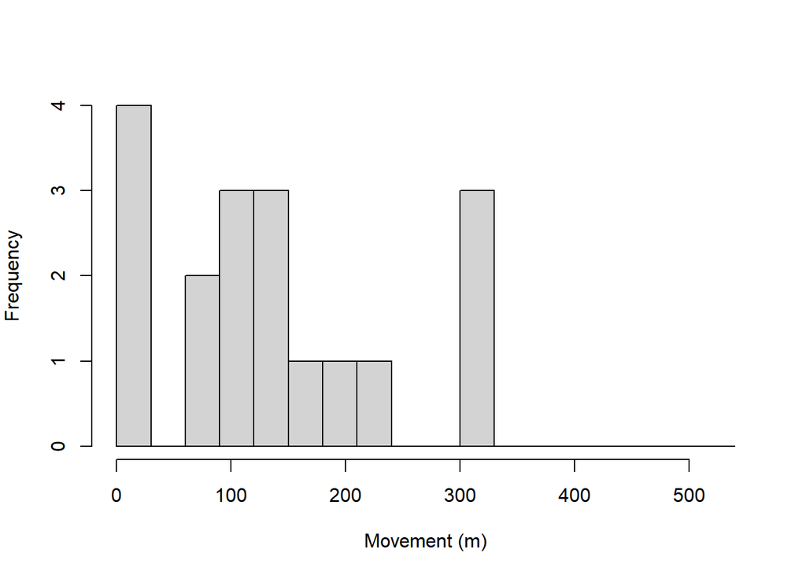

```r
par(mar = c(5,4,4,2), mgp = c(3,1,0)) # reduce margins
hist(m, breaks = seq(0, 550,30), xlab = "Movement (m)", main = "")
```

## Buffer width

View two suggested buffer widths. The first uses an approximation from a circular bivariate normal distribution to estimate sigma, a spatial scale parameter influencing the shape of the decline in capture probability with distance from the home range centre. 4 x sigma is suitable as an initial rule-of thumb buffer width, although it fails to account for a truncation of movements at the edge of the trapping grid (Efford, 2022).

```r
initialsigma <- RPSV(CH, CC = TRUE)
cat("Quick and biased estimate of sigma =", initialsigma, "m\n")
```

```
## Quick and biased estimate of sigma = 77.20445 m
```

```r
4*initialsigma
```

```
## [1] 308.8178
```

The suggest.buffer function requires a detection function as input, here we have included the Half-Normal detection function, but this could be explored with the final chosen function.

```r
suggest.buffer(CH, detectfn = 'HN', RBtarget = 0.001)
```

```
## [1] 305
```

Given the similarity of the two suggested buffer widths, we will go with a width of 300 m. We check this by plotting the decline in detection probability when we fit a simple model, and the decline in estimated density with increasing buffer width.

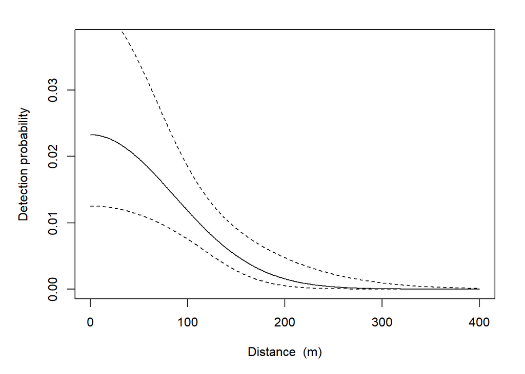

```r
fit.HN <- secr.fit (CH, buffer = 300,
                 detectfn = 'HN',
                 trace = FALSE)

par(mar = c(5,5,2,2)) # reduce margins
plot(fit.HN, limits = TRUE, xval = 0:400)
```

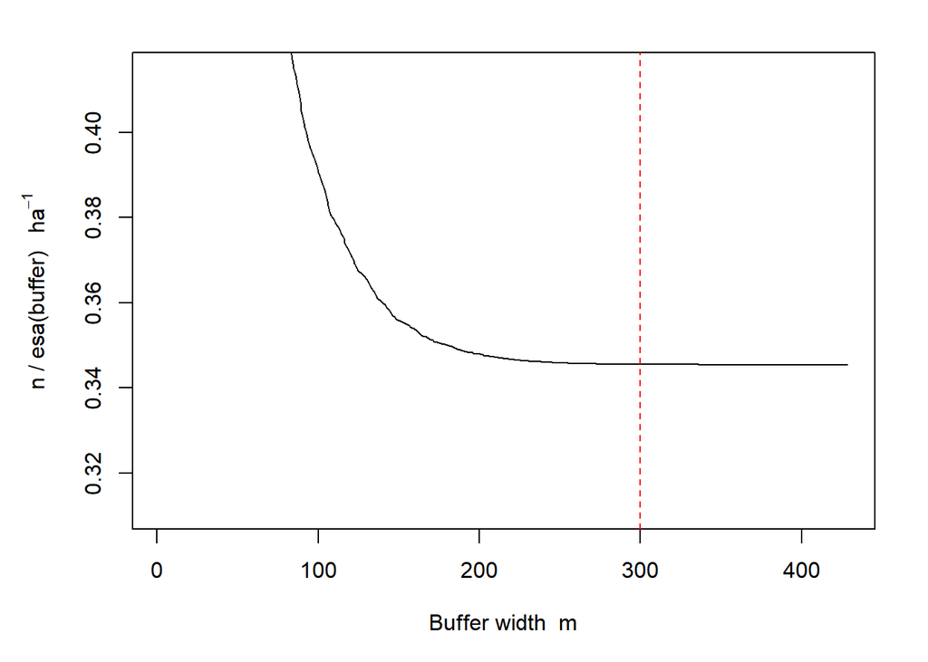

```r
esa.plot(fit.HN)
abline(v = 300, lty = 2, col = 'red')
```

The fitted detection function and esa.plot indicate that a 300 m buffer width is sufficient to encompass all individuals with any non-negligible probability of being captured. The estimated density reaches a plateau before 300m.

## Detection function

We have selected the half-normal detection function for hedgehogs at this site. This is because it is the most commonly-used detection function for modelling mammalian pest detection in New Zealand. Given that parameters sigma and g0 are function-specific, this will provide more comparative values for future studies, assuming that future research might be likely to also model a half-normal detection rate.

We must check the implications of this assumption however, by fitting models with the half-normal, exponential, or hazard rate function and comparing the estimated densities. We also compare model fit via AICc.

```r
#We already have the half-normal (fit.HN)

#Now the exponential
fit.EX <- secr.fit (CH,buffer=300,
                  detectfn = 'EX',
                  trace = FALSE,)

#Now the hazard rate
fit.HR <- secr.fit (CH, buffer = 300,
                    detectfn = 'HR',
                    trace = FALSE)
#Combine into an object of class secrlist
fits<- secrlist(HN = fit.HN, EX = fit.EX, HR = fit.HR)
predict(fits)
```

```
## $HN
##        link    estimate  SE.estimate         lcl          ucl
## D       log  0.34554560  0.080384794  0.22033948   0.54189908
## g0    logit  0.02325441  0.007303396  0.01251859   0.04279812
## sigma   log 85.90193858 11.813537849 65.68869086 112.33506036
##
## $EX
##        link    estimate SE.estimate         lcl        ucl
## D       log  0.35006108  0.08290490  0.22146132  0.5533371
## g0    logit  0.06384291  0.02358404  0.03050871  0.1287612
## sigma   log 51.66015807  9.23367473 36.49283034 73.1314044
##
## $HR
##        link   estimate SE.estimate         lcl          ucl
## D       log  0.3414148  0.08446163  0.21175093   0.55047731
## g0    logit  0.0359970  0.01901489  0.01259673   0.09852906
## sigma   log 66.5173517 24.13430684 33.38825691 132.51839062
## z       log  3.2706101  0.78671317  2.05472122   5.20600581
```

The density estimates and standard errors are similar across detection functions. The estimate for the exponential is slightly higher.

```r
AIC(fits,criterion = 'AICc')
```

```
##                   model    detectfn npar    logLik     AIC    AICc dAICc AICcwt
## EX     D~1 g0~1 sigma~1 exponential    3 -254.3678 514.736 515.625 0.000 0.6670
## HN     D~1 g0~1 sigma~1  halfnormal    3 -255.5919 517.184 518.073 2.448 0.1961
## HR D~1 g0~1 sigma~1 z~1 hazard rate    4 -254.6266 517.253 518.792 3.167 0.1369
```

The most-supported model is the exponential, with an AICc weight of 0.67 and a ΔAICc from the exponential to the half-normal of 2.4. Although this suggess better support for the exponential detection function, due to the reasons mentioned above we shall proceed with the half-normal. Given the minor differences in density values, we perceive little effect of this decision.

## Fitting behavioural models

We have already fitted a null model with the half-normal detection function. We will also consider four other candidate models representing potential behavioural variability during the trapping process. The four models have an additional parameter applied to g0 as a representation of individual behavioural change in response to capture. These are: model b, which depicts a change in capture probability in response to capture that remains throughout the trapping period (Borchers and Efford, 2008; Otis et al., 1978); model bk, a long-term behavioural response to capture that is specific to a trap location; model B, a short-term behavioural response that lasts until the next capture and model Bk, a location-specific transient behavioural response.

```r
#null model
#fit.HN

#b - long-term behavioural step-change
fitb.HN <- secr.fit(CH, buffer = 300,
                    model = list(g0 ~ b, sigma ~ 1),
                    detectfn = 'HN',
                    trace = FALSE, CL = F)

#B - transient behavioural step-change
fitB.HN <- secr.fit(CH, buffer = 300,
                    model = list(g0 ~ B, sigma ~ 1),
                    detectfn = 'HN',
                    trace = FALSE, CL = F)

#bk - site-specific permanent behavioural step-change
fitbk.HN <- secr.fit(CH, buffer = 300,
                    model = list(g0 ~ bk, sigma ~ 1),
                    detectfn = 'HN',
                    trace = FALSE, CL = F)

#Bk - site-specific transient behavioural step-change
fitBk.HN <- secr.fit(CH, buffer = 300,
                    model = list(g0 ~ Bk, sigma ~ 1),
                    detectfn = 'HN',
                    trace = FALSE, CL = F)
```

```r
#now combining to compare via AICc
fits <- secrlist(null = fit.HN,
                b = fitb.HN,
                B = fitB.HN,
                bk = fitbk.HN,
                Bk = fitBk.HN)

AIC(fits,criterion = 'AICc')
```

```
##                  model   detectfn npar    logLik     AIC    AICc dAICc AICcwt
## B     D~1 g0~B sigma~1 halfnormal    4 -250.6467 509.293 510.832 0.000 0.8040
## Bk   D~1 g0~Bk sigma~1 halfnormal    4 -252.3161 512.632 514.171 3.339 0.1514
## null  D~1 g0~1 sigma~1 halfnormal    3 -255.5919 517.184 518.073 7.241 0.0215
## bk   D~1 g0~bk sigma~1 halfnormal    4 -254.5099 517.020 518.558 7.726 0.0169
## b     D~1 g0~b sigma~1 halfnormal    4 -255.5236 519.047 520.586 9.754 0.0061
```

Now we look at the predicted density, sigma, and g0 values for each model.

```r
predict(fits)
```

```
## $null
##        link    estimate  SE.estimate         lcl          ucl
## D       log  0.34554560  0.080384794  0.22033948   0.54189908
## g0    logit  0.02325441  0.007303396  0.01251859   0.04279812
## sigma   log 85.90193858 11.813537849 65.68869086 112.33506036
##
## $b
##        link    estimate SE.estimate          lcl          ucl
## D       log  0.31176614  0.10368591  0.165246013   0.58820256
## g0    logit  0.02796543  0.01528633  0.009465499   0.07971298
## sigma   log 85.85377720 11.79853081 65.664253468 112.25089253
##
## $B
##        link   estimate  SE.estimate          lcl          ucl
## D       log  0.4604537  0.137717623  0.259437290   0.81722111
## g0    logit  0.0150501  0.005783502  0.007062306   0.03178327
## sigma   log 85.6652499 11.743053979 65.563783885 111.92970576
##
## $bk
##        link    estimate  SE.estimate          lcl          ucl
## D       log  0.37403284  0.096857762  0.227014430   0.61626289
## g0    logit  0.01646374  0.006661933  0.007418335   0.03613696
## sigma   log 94.81927046 15.552700881 68.897613282 130.49354864
##
## $Bk
##        link    estimate  SE.estimate          lcl          ucl
## D       log  0.36626474  0.090851778  0.226881372   0.59127754
## g0    logit  0.01804629  0.006223901  0.009148368   0.03529033
## sigma   log 92.29828458 13.843359896 68.902585425 123.63793440
```

```r
summary(fitB.HN, B = F)
```

```
## $versiontime
## [1] "4.5.8, run 16:09:36 24 Mar 2023, elapsed 13.15 s"
##
## $traps
##  Detector Number  Spacing UsagePct
##     multi     89 91.01169      100
##
## $capthist
##  Occasions Detections    Animals  Detectors      Moves   Animals2
##         15         49         31         89         14          8
##
## $mask
##  Cells  Spacing     Area
##   3000 28.54267 244.4052
##
## $modeldetails
##     CL fixed distribution hcov
##  FALSE  none      poisson
##
## $AICtable
##             model   detectfn npar    logLik     AIC    AICc
##  D~1 g0~B sigma~1 halfnormal    4 -250.6467 509.293 510.832
##
## $coef
##                beta   SE.beta       lcl        ucl
## D        -0.7755429 0.2927081 -1.349240 -0.2018456
## g0       -4.1812062 0.3901552 -4.945896 -3.4165160
## g0.BTRUE  1.5544302 0.4717425  0.629832  2.4790285
## sigma     4.4504473 0.1364432  4.183023  4.7178710
##
## $predicted
##        link   estimate  SE.estimate          lcl          ucl
## D       log  0.4604537  0.137717623  0.259437290   0.81722111
## g0    logit  0.0150501  0.005783502  0.007062306   0.03178327
## sigma   log 85.6652499 11.743053979 65.563783885 111.92970576
```

Now we will extract the values of g0 for alternate states of parameter B (captured 1, or not captured 0).

```r
predict(fitB.HN, newdata = data.frame(B = 0:1), realnames = "g0")
```

```
## $`B = 0`
##     link  estimate SE.estimate         lcl        ucl
## g0 logit 0.0150501 0.005783502 0.007062306 0.03178327
##
## $`B = 1`
##     link   estimate SE.estimate        lcl       ucl
## g0 logit 0.06743492  0.02666492 0.03053648 0.1423715
```

This indicates an increase in g0 when parameter B was true – namely, for the trapping occasion following when an individual had been captured.

Plot the fitted detection function

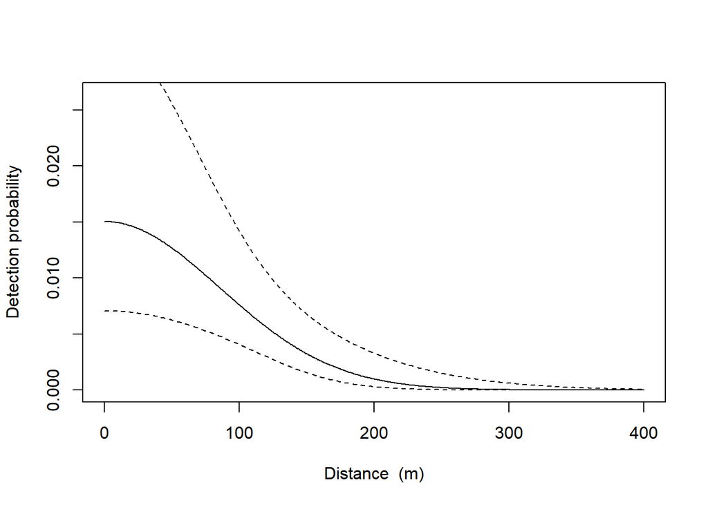

```r
plot(fitB.HN, limits = TRUE, xval = 0:400)
```

## Re-checking the detection function with final model

We re-run the models with the exponential and hazard rate detection functions. Once again, the exponential is the most well-supported according to AICc, and the final density values do not differ substantially among models.

```r
fitB.EX <- secr.fit(CH, buffer = 300,
                    model = list(g0 ~ B, sigma ~ 1),
                    detectfn = 'EX',
                    trace = FALSE, CL = F)


fitB.HR <- secr.fit(CH, buffer = 300,
                    model = list(g0 ~ B, sigma ~ 1),
                    detectfn = 'HR',
                    trace = FALSE, CL = F)
fits <- secrlist(HN = fitB.HN,
                 EX = fitB.EX,
                 HR = fitB.HR)

predict(fits)
```

```
## $HN
##        link   estimate  SE.estimate          lcl          ucl
## D       log  0.4604537  0.137717623  0.259437290   0.81722111
## g0    logit  0.0150501  0.005783502  0.007062306   0.03178327
## sigma   log 85.6652499 11.743053979 65.563783885 111.92970576
##
## $EX
##        link    estimate SE.estimate         lcl         ucl
## D       log  0.46716537  0.14139370  0.26149748  0.83459114
## g0    logit  0.04114048  0.01767862  0.01751355  0.09360489
## sigma   log 51.54024502  9.11458989 36.54044795 72.69743548
##
## $HR
##        link    estimate SE.estimate          lcl          ucl
## D       log  0.45886030  0.14239338  0.253269814   0.83133783
## g0    logit  0.02252169  0.01306175  0.007150516   0.06865091
## sigma   log 67.84037461 25.28211214 33.460018262 137.54673983
## z       log  3.33137184  0.82734041  2.062451046   5.38099481
```

```r
AIC(fits,criterion = 'AICc')
```

```
##                   model    detectfn npar    logLik     AIC    AICc dAICc AICcwt
## EX     D~1 g0~B sigma~1 exponential    4 -249.4439 506.888 508.426 0.000 0.6803
## HN     D~1 g0~B sigma~1  halfnormal    4 -250.6467 509.293 510.832 2.406 0.2043
## HR D~1 g0~B sigma~1 z~1 hazard rate    5 -249.7876 509.575 511.975 3.549 0.1154
```

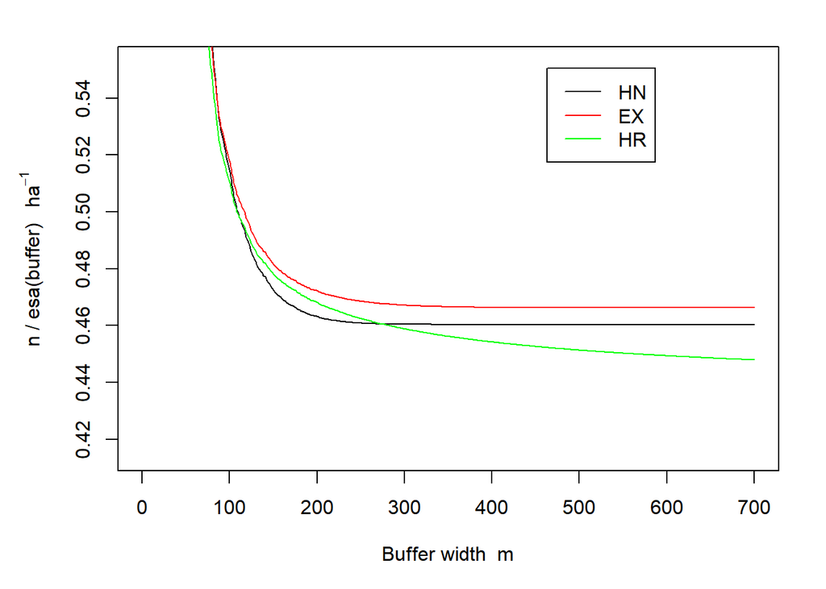

```r
par(mar = c(5,5,2,2))
esa.plot(fits, max.buffer = 700)
```

## References

Borchers, D. L., and M. G. Efford. 2008. Spatially explicit maximum likelihood methods for capture– recapture studies. Biometrics 64:377–385.

Efford, M. 2022. A tutorial on fitting spatially explicit capture–recapture models in secr. https://www.otago.ac.nz/density/pdfs/secr-tutorial.pdf.

Otis, D. L., K. P. Burnham, G. C. White, and D. R. Anderson. 1978. Statistical inference from capture data on closed animal populations. Wildlife Monographs:3–135.